# Análise de Desempenho de Vendedores

Marcelo Pariz Júnior

10/01/2022

## Objetivo

O objetivo deste relatório é apresentar resultados importantes para auxiliar a equipe de gestão a determinar o desempenho dos vendedores da empresa.

Trata-se de uma empresa real, com resultados reais; usada como modelo. Uma empresa do ramo de representações têxteis, responsável por atender clientes em todo território nacional.

Site da empresa: [TABATEX](http://www.tabatex.com.br/)

## Os dados

Primeiro gráfico ilustra os 10 vendedores que mais orçaram e as quantidades de itens, uma informação fundamental para tomada de decisão.

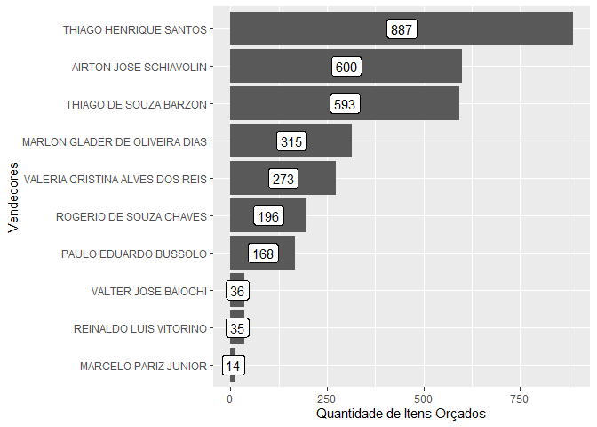

No segundo gráfico, podemos ver os 10 vendedores que mais venderam.

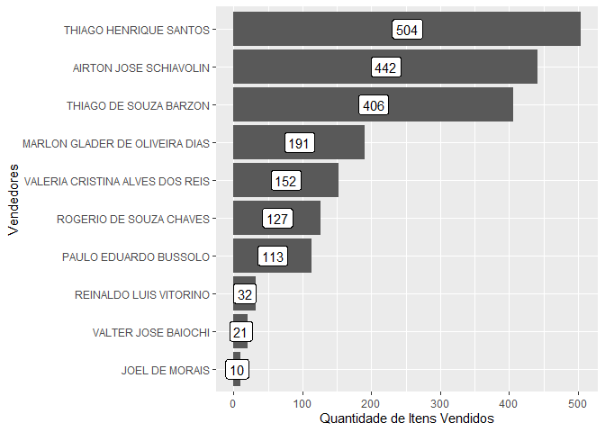

No terceiro gráfico, podemos ver os 10 vendedores mais eficientes; comparando a quantidade de itens orçados com itens vendidos.

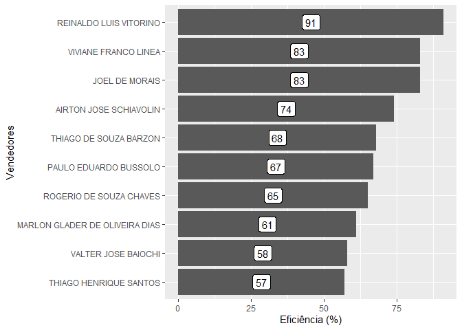

O quarto gráfico traz uma das informações mais importantes: dentre os itens que não foram vendidos, quantos possuíam saldo positivo em estoque (em porcentagem).

O maior motivo usado pelos vendedores para justificar um orçamento não finalizado, é justamente o saldo em estoque. Esse gráfico nos mostra se realmente este é um motivo plausível.

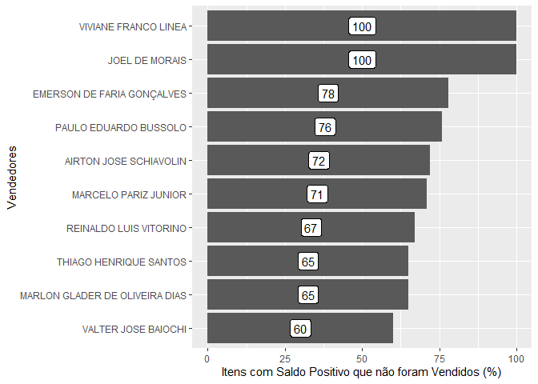

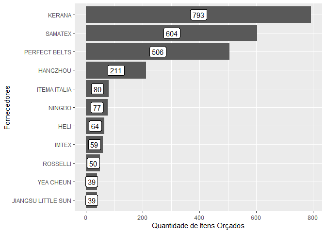

## Resumo dos Dados Obtidos com a Análise

A seguir uma tabela com o resumo dos dados obtidos com esta análise:

Número de itens orçados por vendedor, número de itens vendidos, quantidade de itens não vendidos que possuíam saldo positivo em estoque e a eficiência em porcentagem de cada vendedor.

| Vendedor | Itens_Orcados | Itens_Vendidos | Itens_com_Saldo_Positivo | Eficiencia |
| --- | --- | --- | --- | --- |
| VALERIA CRISTINA ALVES DOS REIS | 273 | 152 | 70 | 56 |
| AIRTON JOSE SCHIAVOLIN | 600 | 442 | 114 | 74 |
| THIAGO HENRIQUE SANTOS | 887 | 504 | 248 | 57 |
| VALTER JOSE BAIOCHI | 36 | 21 | 9 | 58 |
| THIAGO DE SOUZA BARZON | 593 | 406 | 104 | 68 |
| MARLON GLADER DE OLIVEIRA DIAS | 315 | 191 | 80 | 61 |
| ROGERIO DE SOUZA CHAVES | 196 | 127 | 35 | 65 |
| REINALDO LUIS VITORINO | 35 | 32 | 2 | 91 |
| PAULO EDUARDO BUSSOLO | 168 | 113 | 42 | 67 |
| MARCELO PARIZ JUNIOR | 14 | 7 | 5 | 50 |
| EMERSON DE FARIA GONÇALVES | 9 | 0 | 7 | 0 |
| VIVIANE FRANCO LINEA | 6 | 5 | 1 | 83 |
| JOEL DE MORAIS | 12 | 10 | 2 | 83 |